# Comparing elpd_diff values for Hindi and Hindi-Kabardian

Amelia

16/08/2019

## Parameters/ “degrees of freedom” affecting model results

### Data Parameters

#### design

1. number of subjects: 30
2. number of trials: 144

#### data sampling/predictors:

3. intercept = 1.3592 (based on pilots)
4. values: acoustic distances and Econ, Glob,Loc assigned based on design  
   (https://docs.google.com/spreadsheets/d/1p-oHTYW3BOV3RMQPRBK8-JrQrIGJIOSUXm-C1fGeAk8/edit#gid=1153981776)
   - acoustic distances include jitter for each instance of a phone; Econ, Glob, Loc do not
5. coefficients:
   - data sampled based on Econ, Glob,Loc each given coef of -1,0,1
   - coef of acoustic distance based on pilots: -.1784
6. Number of datasets =1 (this document compares only one instance of each dataset, but pipeline includes tools to sample multiple)

### Model Parameters

7. iterations: 2000
8. chains: 4
9. positive constrained priors:
   - normal(0,10), truncated at 0 by specifying <lower=0>
10. parameters of the horseshoe prior, appled to negative constrained priors:
    - real<lower=0> scale_global; // scale for the half-t prior for tau
    - real<lower=1> nu_global; // degrees of freedom for the half-t prior for tau
    - real<lower=0> nu_local; // degrees of freedom for the half-t prior for lambdas
    - real<lower=0> slab_scale; // slab scale for the regularized horseshoe
    - real<lower=0> slab_df; // slab degrees of freedom for the regularized horseshoe

## Hindi-Kabardian

### overall elpd_diff vs. se_diff

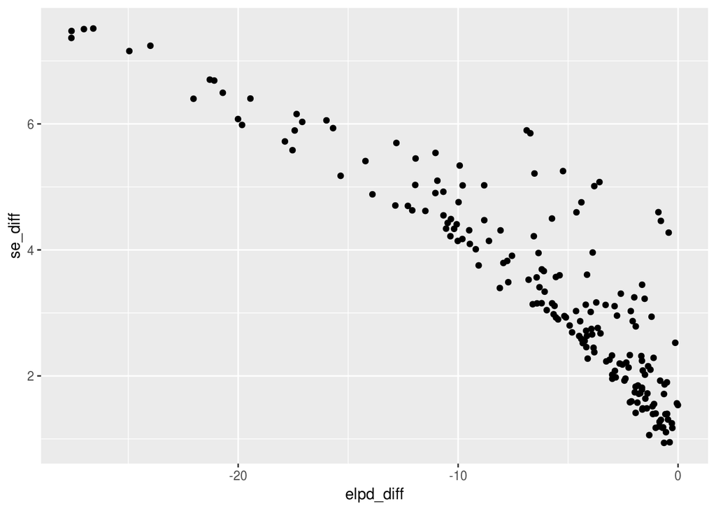

### elpd_diff based on number of coeffs values that matching the model used

(prediction: more matching coeffs, smaller elpd_diffs )

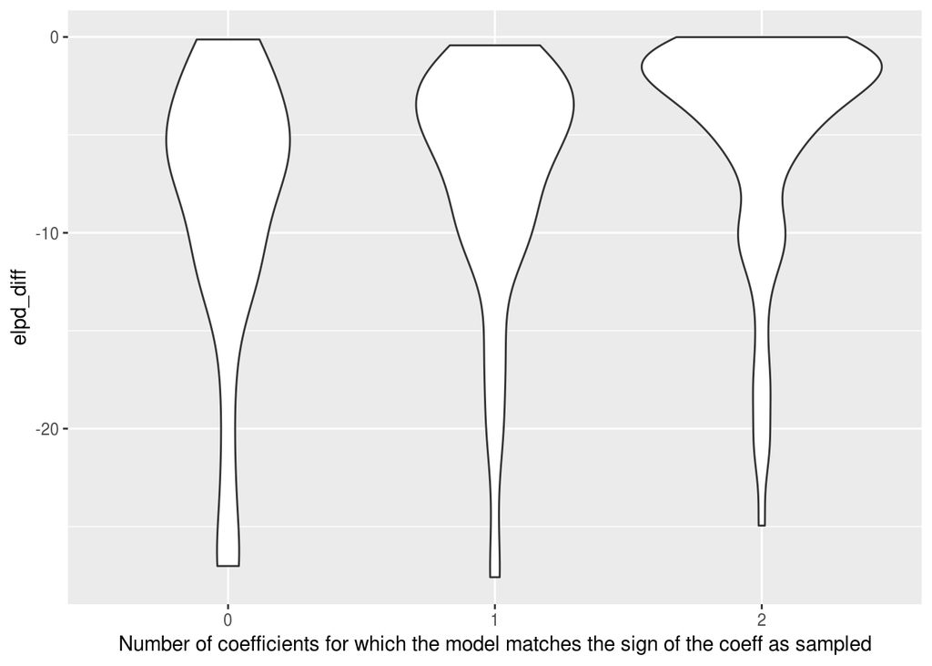

### se_diff based on number of coeffs values that matching the model used

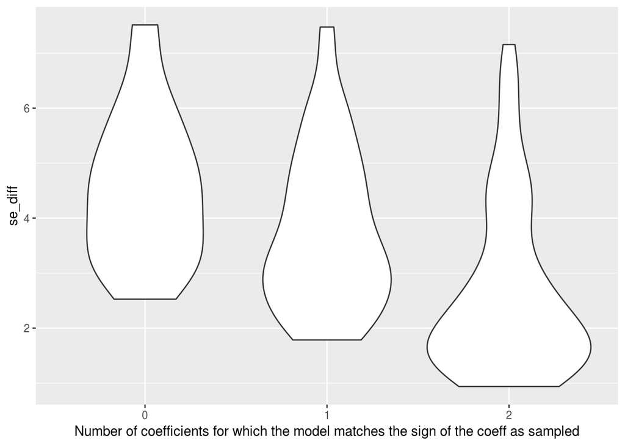

### elpd_diff based on number of zero coeffs sampled

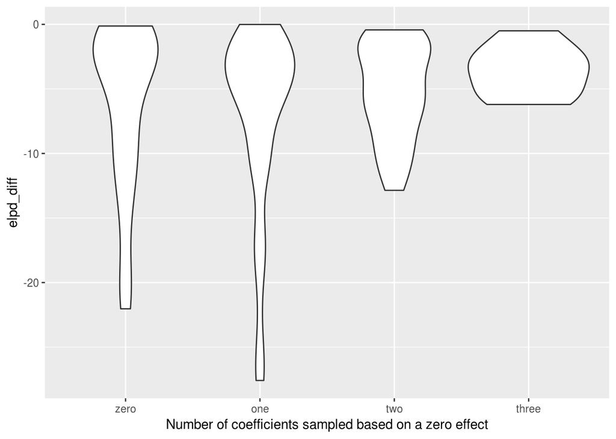

### se_diff based on number of zero coeffs sampled

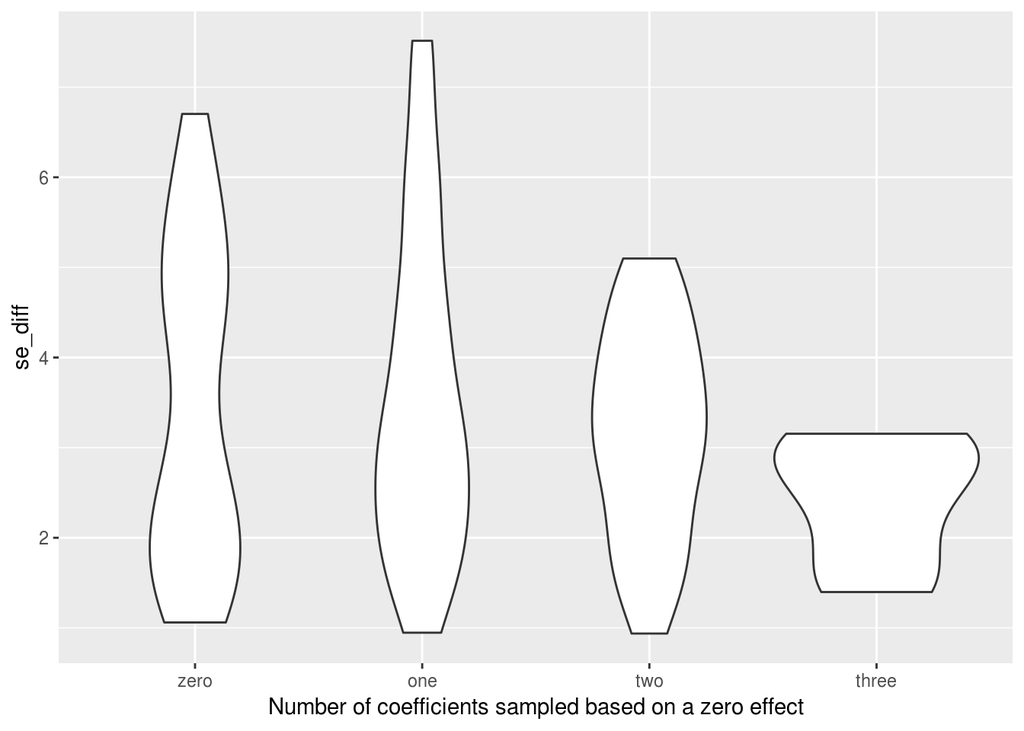